# Coursework Report

*N* removed NAs: 3

*N* removed <18: 20

*N* total clean: 125

| Group | *N* | *M*<sub>age</sub> | *M*<sub>rating</sub> |
| --- | --- | --- | --- |
| Control | 60 | 20.68 | 5.27 |
| Experim | 65 | 20.72 | 6.34 |

**Main analysis results**

*t*(123) = -8.91, *p* < .001

# Coursework Report

Analysing Data, Spring 2020

# **Methods**

## Participants

| GROUP | mean_age | sd_age | min_age | max_age |
| --- | --- | --- | --- | --- |
| control | 20.68333 | 2.325188 | 18 | 26 |
| experimental | 20.72308 | 2.042576 | 18 | 27 |

## Design

This experiment aims to determine if colour influences attractiveness.In this experiment, the independent variable was categorical; the colour used for the frame of the picture of a person shown to the participant. The control condition was a white frame while the experimental condition was a red frame. The dependent variable was continuous; attractiveness rated on a scale of 1 - 9, and was based on three questions: “How attractive do you think this person is?”, “How pleasant is this person to look at?”, and “If I were to meet the person in this picture face to face, I would think he is attractive.”.

The effect of a red-coloured frame around an image of a moderately attractive man will positively influence his mean ratings of attractiveness. This will be examined by creating a composite score from the three variables measured and plotting the mean composite score based on the experimental condition (colour group), which will then be analysed using the t-test to determine if there is a significant difference between the colour groups.

# **Results**

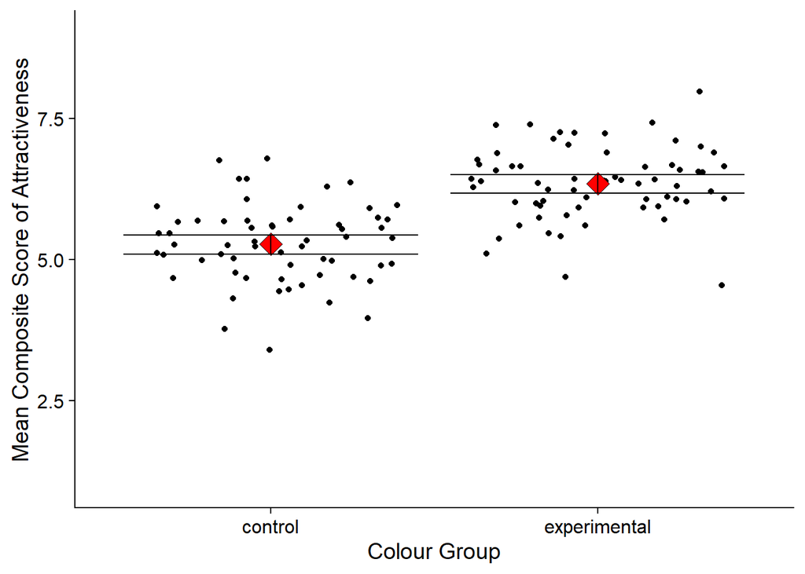

The results plotted above demonstrate that the use of a red-coloured frame positively influences the mean attractiveness rating of the individual in the image as the mean rating of attractiveness is higher in the experimental group (6.34) than the control group (5.27). According to the t-test analysis, there was a significant difference in the mean attractiveness ratings between the red and white colour groups (M<sub>diff</sub> = -1.07, 95% CI [-1.31,-0.83],t(123) = -8.91, p <.001). This analysis shows that the results obtained are what can be seen in the general population.

# **Discussion**

In this experiment, when the frame used was red, the participants tended to give higher ratings of attractiveness to the man in the image whilst those framed in white had lower ratings of attractiveness. The results from this experiment suggest that the colour red makes individuals more attractive in the eyes of others. Being a follow up to the study conducted by Elliot and colleagues (2010), this experiment contributes further evidence to support the colour red having an influence over women’s perception of male attractiveness as this experiment has similar results to the original study.

The results from this study are contrasted by the study conducted by Peperkoorn and colleagues (2016), where three experiments were conducted to test the effect of red on attractiveness and results from all three experiments failed to support the effect. Additionally, a meta-analysis of studies on the effect of red on attractiveness has demonstrated that the effect is very small and almost non-existent (Lehmann et al., 2018). In a different replication of the original study, results challenged the significance of the effect of red on attractiveness (Hesslinger et al., 2015). This contrast between studies suggests that further research should be done by improving on the experimental design to improve replicability by others so as to obtain more data to better understand the effect.

This experiment has demonstrated a significant effect of the colour red on women’s perceived attractiveness of men however these results may be limited by the design of the experiment. This study focuses on a limited age range of 18-27 which makes the results difficult to apply to populations of other ages. Additionally, the study does not take into account the possible influence of personal preference on perceived attractiveness as it follows an independent measures design where the participants in each group were different and hence individual differences would have a greater effect.

Despite results opposing other previous studies, the effect is likely to still be significant as the results of this replication are similar to the original study conducted by Elliot and colleagues (2010). In addition to this, similar results have been found in different cultures from the western world, such as Burkina Faso, which suggest that the effect of red on attractiveness is significant and possible universal (Elliot et al., 2013). However, considering the limitations of the design, the effect of red on attractiveness should be investigated further whilst addressing the issues of the current experiment. For example, a repeated measures design can be utilised to limit the influence of individual differences on perceived attraction and different age groups can be used to compare results between different ages.

In conclusion, the colour red has a positive effect on women’s perception of men’s attractiveness. Further research should be conducted to improve on the validity and replicability of the experiment and its results, as well as to improve generalisability to the general population by exploring the effect for different age groups as well as for different sexes.

# **References**

Elliot, A. J., Kayser, D. N., Greitemeyer, T., Lichtenfeld, S., Gramzow, R. H., Maier, M. A., & Liu, H. (2010). Red, rank, and romance in women viewing men. *Journal of Experimental Psychology: General*, 139(3), 399–417.

Elliot, A. J., Tracy, J. L., Pazda, A. D., & Beall, A. T. (2013). Red enhances womens attractiveness to men: First evidence suggesting universality. *Journal of Experimental Social Psychology*, 49(1), 165–168.

Hesslinger, V. M., Goldbach, L., & Carbon, C.-C. (2015). Men in red: A reexamination of the red-attractiveness effect. *Psychonomic Bulletin & Review*, 22(4), 1142–1148.

Lehmann, G. K., Elliot, A. J., & Calin-Jageman, R. J. (2018). Meta-Analysis of the Effect of Red on Perceived Attractiveness. *Evolutionary Psychology*, 16(4), 147470491880241.

Peperkoorn, L. S., Roberts, S. C., & Pollet, T. V. (2016). Revisiting the Red Effect on Attractiveness and Sexual Receptivity. *Evolutionary Psychology*, 14(4), 147470491667384.